# Project Part I: Communicate Data Findings - [Fordgobike-trip]

## by Oluwadamilare Shiji

### INTRODUCTION

This dataset consist of 16 characteristics and 183,412 observations taken in a bike-sharing system that covers the greater San Francisco Bay area. The dataset can be found here. [GoBike](https://www.lyft.com/bikes/bay-wheels/system-data)

> Each trip is anonymized and includes:
> - Trip Duration (seconds)
> - Start Time and Date
> - End Time and Date
> - Start Station ID
> - Start Station Name
> - Start Station Latitude
> - Start Station Longitude
> - End Station ID
> - End Station Name
> - End Station Latitude
> - End Station Longitude
> - Ride ID
> - User Type (Subscriber or Customer – “Subscriber” = Member or “Customer” = Casual)

### IMPORTING THE NECESSARY PYTHON LIBRARIES

```python
import pandas as pd
import numpy as np
import matplotlib.pyplot as plt
%matplotlib inline
import seaborn as sns
sns.set_style('darkgrid')
```

### DATA GATHERING AND GATHERING

There are two types of data accessing, which are

- Visual data accessing and,
- programmatic data accessing

Accessing of data is done to check for:

- Quality issues such as consistency, validity, accuracy,completeness and
- Tidiness issues.

### Visual Data Accessing

```python
ford_bike = pd.read_csv(r"C:\Users\MICHAEL\DA_Project\Module_3 Project\SUBMIT PROJECT\201902-fordgobike-tripdata.csv")
ford_bike.head()
```

|  | duration_sec | start_time | end_time | start_station_id | start_station_name | start_station_latitude | start_station_longitude | end_station_id | end_station_name | end_station_latitude | end_station_longitude | bike_id | user_type | member_birth_year | member_gender | bike_share_for_all_trip |
| --- | --- | --- | --- | --- | --- | --- | --- | --- | --- | --- | --- | --- | --- | --- | --- | --- |
| 0 | 52185 | 2019-02-28 17:32:10.1450 | 2019-03-01 08:01:55.9750 | 21.0 | Montgomery St BART Station (Market St at 2nd St) | 37.789625 | -122.400811 | 13.0 | Commercial St at Montgomery St | 37.794231 | -122.402923 | 4902 | Customer | 1984.0 | Male | No |
| 1 | 42521 | 2019-02-28 18:53:21.7890 | 2019-03-01 06:42:03.0560 | 23.0 | The Embarcadero at Steuart St | 37.791464 | -122.391034 | 81.0 | Berry St at 4th St | 37.775880 | -122.393170 | 2535 | Customer | NaN | NaN | No |
| 2 | 61854 | 2019-02-28 12:13:13.2180 | 2019-03-01 05:24:08.1460 | 86.0 | Market St at Dolores St | 37.769305 | -122.426826 | 3.0 | Powell St BART Station (Market St at 4th St) | 37.786375 | -122.404904 | 5905 | Customer | 1972.0 | Male | No |
| 3 | 36490 | 2019-02-28 17:54:26.0100 | 2019-03-01 04:02:36.8420 | 375.0 | Grove St at Masonic Ave | 37.774836 | -122.446546 | 70.0 | Central Ave at Fell St | 37.773311 | -122.444293 | 6638 | Subscriber | 1989.0 | Other | No |
| 4 | 1585 | 2019-02-28 23:54:18.5490 | 2019-03-01 00:20:44.0740 | 7.0 | Frank H Ogawa Plaza | 37.804562 | -122.271738 | 222.0 | 10th Ave at E 15th St | 37.792714 | -122.248780 | 4898 | Subscriber | 1974.0 | Male | Yes |

```python
# to get the dimension of the dataset
ford_bike.shape
```

```
(183412, 16)
```

```python
ford_bike.tail()
```

|  | duration_sec | start_time | end_time | start_station_id | start_station_name | start_station_latitude | start_station_longitude | end_station_id | end_station_name | end_station_latitude | end_station_longitude | bike_id | user_type | member_birth_year | member_gender | bike_share_for_all_trip |
| --- | --- | --- | --- | --- | --- | --- | --- | --- | --- | --- | --- | --- | --- | --- | --- | --- |
| 183407 | 480 | 2019-02-01 00:04:49.7240 | 2019-02-01 00:12:50.0340 | 27.0 | Beale St at Harrison St | 37.788059 | -122.391865 | 324.0 | Union Square (Powell St at Post St) | 37.788300 | -122.408531 | 4832 | Subscriber | 1996.0 | Male | No |
| 183408 | 313 | 2019-02-01 00:05:34.7440 | 2019-02-01 00:10:48.5020 | 21.0 | Montgomery St BART Station (Market St at 2nd St) | 37.789625 | -122.400811 | 66.0 | 3rd St at Townsend St | 37.778742 | -122.392741 | 4960 | Subscriber | 1984.0 | Male | No |
| 183409 | 141 | 2019-02-01 00:06:05.5490 | 2019-02-01 00:08:27.2200 | 278.0 | The Alameda at Bush St | 37.331932 | -121.904888 | 277.0 | Morrison Ave at Julian St | 37.333658 | -121.908586 | 3824 | Subscriber | 1990.0 | Male | Yes |
| 183410 | 139 | 2019-02-01 00:05:34.3600 | 2019-02-01 00:07:54.2870 | 220.0 | San Pablo Ave at MLK Jr Way | 37.811351 | -122.273422 | 216.0 | San Pablo Ave at 27th St | 37.817827 | -122.275698 | 5095 | Subscriber | 1988.0 | Male | No |
| 183411 | 271 | 2019-02-01 00:00:20.6360 | 2019-02-01 00:04:52.0580 | 24.0 | Spear St at Folsom St | 37.789677 | -122.390428 | 37.0 | 2nd St at Folsom St | 37.785000 | -122.395936 | 1057 | Subscriber | 1989.0 | Male | No |

### Programmatic Data Accessing

```python
# to get further information on the dataset
ford_bike.info()
```

```
<class 'pandas.core.frame.DataFrame'>
RangeIndex: 183412 entries, 0 to 183411
Data columns (total 16 columns):
 #   Column                   Non-Null Count   Dtype
---  ------                   --------------   -----
 0   duration_sec             183412 non-null  int64
 1   start_time               183412 non-null  object
 2   end_time                 183412 non-null  object
 3   start_station_id         183215 non-null  float64
 4   start_station_name       183215 non-null  object
 5   start_station_latitude   183412 non-null  float64
 6   start_station_longitude  183412 non-null  float64
 7   end_station_id           183215 non-null  float64
 8   end_station_name         183215 non-null  object
 9   end_station_latitude     183412 non-null  float64
 10  end_station_longitude    183412 non-null  float64
 11  bike_id                  183412 non-null  int64
 12  user_type                183412 non-null  object
 13  member_birth_year        175147 non-null  float64
 14  member_gender            175147 non-null  object
 15  bike_share_for_all_trip  183412 non-null  object
dtypes: float64(7), int64(2), object(7)
memory usage: 22.4+ MB
```

```python
sum(ford_bike.duplicated())
```

```
0
```

```python
ford_bike.isnull().sum()
```

```
duration_sec                  0
start_time                    0
end_time                      0
start_station_id            197
start_station_name          197
start_station_latitude        0
start_station_longitude       0
end_station_id              197
end_station_name            197
end_station_latitude          0
end_station_longitude         0
bike_id                       0
user_type                     0
member_birth_year          8265
member_gender              8265
bike_share_for_all_trip       0
dtype: int64
```

```python
ford_bike.describe()
```

|  | duration_sec | start_station_id | start_station_latitude | start_station_longitude | end_station_id | end_station_latitude | end_station_longitude | bike_id | member_birth_year |
| --- | --- | --- | --- | --- | --- | --- | --- | --- | --- |
| count | 183412.000000 | 183215.000000 | 183412.000000 | 183412.000000 | 183215.000000 | 183412.000000 | 183412.000000 | 183412.000000 | 175147.000000 |
| mean | 726.078435 | 138.590427 | 37.771223 | -122.352664 | 136.249123 | 37.771427 | -122.352250 | 4472.906375 | 1984.806437 |
| std | 1794.389780 | 111.778864 | 0.099581 | 0.117097 | 111.515131 | 0.099490 | 0.116673 | 1664.383394 | 10.116689 |
| min | 61.000000 | 3.000000 | 37.317298 | -122.453704 | 3.000000 | 37.317298 | -122.453704 | 11.000000 | 1878.000000 |
| 25% | 325.000000 | 47.000000 | 37.770083 | -122.412408 | 44.000000 | 37.770407 | -122.411726 | 3777.000000 | 1980.000000 |
| 50% | 514.000000 | 104.000000 | 37.780760 | -122.398285 | 100.000000 | 37.781010 | -122.398279 | 4958.000000 | 1987.000000 |
| 75% | 796.000000 | 239.000000 | 37.797280 | -122.286533 | 235.000000 | 37.797320 | -122.288045 | 5502.000000 | 1992.000000 |
| max | 85444.000000 | 398.000000 | 37.880222 | -121.874119 | 398.000000 | 37.880222 | -121.874119 | 6645.000000 | 2001.000000 |

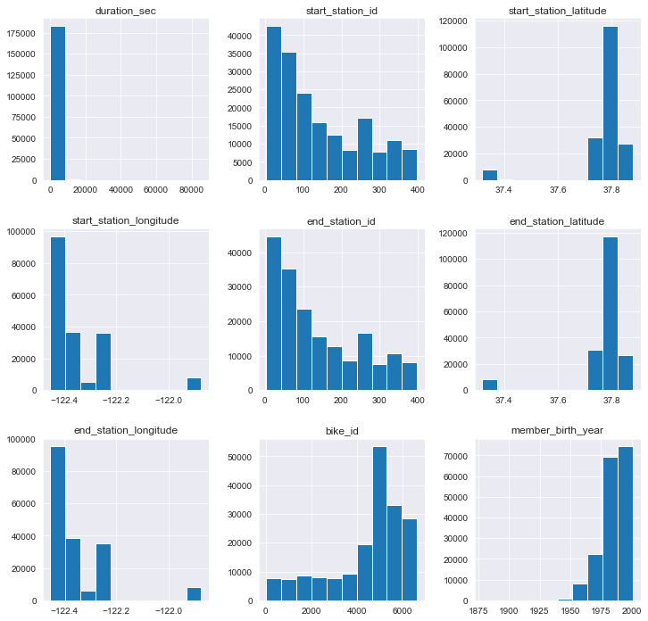

```python
ford_bike.hist(figsize = (12,12));
```

After wrangling, I noticed that:

- There were no duplicate values.
- There are missing values.
- The `date` and `year` datatypes are datatypes of object and float respectively which needs to be changed
- The `start_station_id`and `end_station_id` datatypes are of datatypes float which also needs to be changed.
- The `user_type` and `member_gender` datatype should be changed to category datatype.
- The `start_station_latitude`, `start_station_longitude`, `end_station_latitude`, `end_station_longitude` datatypes should be changed to object datatypes.

### DATA CLEANING

```python
# creating a copy of the dataset
ford_bike_clean = ford_bike.copy()
```

```python
# removing null rows from the dataset
ford_bike_clean.dropna(axis = 0 , inplace = True)
```

```python
# Extracting the 'member_age' of members from the 'member_birth_year' colunm
ford_bike_clean['member_age'] = 2022 - ford_bike_clean['member_birth_year']
```

```python
# changing the datatype of the start_station_id, end_station_id, 'member_age' to int
for b in ['start_station_id', 'end_station_id','member_age']:
    ford_bike_clean[b] = ford_bike_clean[b].astype(int)
```

```python
# changing the datatype of the member_gender, end_station_id to int
for c in ['member_gender', 'user_type']:
    ford_bike_clean[c] = ford_bike_clean[c].astype('category')
```

```python
# changing the datatype of the `start_time`, `end_time` to datetime
ford_bike_clean[['start_time','end_time']] = ford_bike_clean[['start_time','end_time']].apply(pd.to_datetime, errors='coerce')
```

```python
# adding a new column 'duration_min'
ford_bike_clean['duration_min'] = ford_bike_clean['duration_sec']/60
```

```python
# adding a new column 'duration_hour'
ford_bike_clean['duration_hour'] = ford_bike_clean['duration_sec']/3600
```

```python
# to extract month of the 'start_week' column
ford_bike_clean['start_month'] = pd.to_datetime(ford_bike_clean['start_time']).dt.month_name()
```

```python
ford_bike_clean['start_hour'] = pd.to_datetime(ford_bike_clean['start_time']).dt.hour
```

```python
# to extract day of the 'start_week' column
ford_bike_clean['start_week'] = pd.to_datetime(ford_bike_clean['start_time']).dt.day_name()
```

```python
# dropping unwanted columns such as `start_station_latitude`, `start_station_longitude`, `end_station_latitude`, `end_station_longitude`.
ford_bike_clean.drop(['start_station_latitude', 'start_station_longitude', 'end_station_latitude', 'end_station_longitude', 'member_birth_year'], axis = 1, inplace = True)
```

### Confirming the changes made during data cleaning

```python
ford_bike_clean.isnull().sum()
```

```
duration_sec               0
start_time                 0
end_time                   0
start_station_id           0
start_station_name         0
end_station_id             0
end_station_name           0
bike_id                    0
user_type                  0
member_gender              0
bike_share_for_all_trip    0
member_age                 0
duration_min               0
duration_hour              0
start_month                0
start_hour                 0
start_week                 0
dtype: int64
```

```python
ford_bike_clean.info()
```

```
<class 'pandas.core.frame.DataFrame'>
Int64Index: 174952 entries, 0 to 183411
Data columns (total 17 columns):
 #   Column                   Non-Null Count   Dtype
---  ------                   --------------   -----
 0   duration_sec             174952 non-null  int64
 1   start_time               174952 non-null  datetime64[ns]
 2   end_time                 174952 non-null  datetime64[ns]
 3   start_station_id         174952 non-null  int32
 4   start_station_name       174952 non-null  object
 5   end_station_id           174952 non-null  int32
 6   end_station_name         174952 non-null  object
 7   bike_id                  174952 non-null  int64
 8   user_type                174952 non-null  category
 9   member_gender            174952 non-null  category
 10  bike_share_for_all_trip  174952 non-null  object
 11  member_age               174952 non-null  int32
 12  duration_min             174952 non-null  float64
 13  duration_hour            174952 non-null  float64
 14  start_month              174952 non-null  object
 15  start_hour               174952 non-null  int64
 16  start_week               174952 non-null  object
dtypes: category(2), datetime64[ns](2), float64(2), int32(3), int64(3), object(5)
memory usage: 19.7+ MB
```

```python
ford_bike_clean.head()
```

|  | duration_sec | start_time | end_time | start_station_id | start_station_name | end_station_id | end_station_name | bike_id | user_type | member_gender | bike_share_for_all_trip | member_age | duration_min | duration_hour | start_month | start_hour | start_week |
| --- | --- | --- | --- | --- | --- | --- | --- | --- | --- | --- | --- | --- | --- | --- | --- | --- | --- |
| 0 | 52185 | 2019-02-28 17:32:10.145 | 2019-03-01 08:01:55.975 | 21 | Montgomery St BART Station (Market St at 2nd St) | 13 | Commercial St at Montgomery St | 4902 | Customer | Male | No | 38 | 869.750000 | 14.495833 | February | 17 | Thursday |
| 2 | 61854 | 2019-02-28 12:13:13.218 | 2019-03-01 05:24:08.146 | 86 | Market St at Dolores St | 3 | Powell St BART Station (Market St at 4th St) | 5905 | Customer | Male | No | 50 | 1030.900000 | 17.181667 | February | 12 | Thursday |
| 3 | 36490 | 2019-02-28 17:54:26.010 | 2019-03-01 04:02:36.842 | 375 | Grove St at Masonic Ave | 70 | Central Ave at Fell St | 6638 | Subscriber | Other | No | 33 | 608.166667 | 10.136111 | February | 17 | Thursday |
| 4 | 1585 | 2019-02-28 23:54:18.549 | 2019-03-01 00:20:44.074 | 7 | Frank H Ogawa Plaza | 222 | 10th Ave at E 15th St | 4898 | Subscriber | Male | Yes | 48 | 26.416667 | 0.440278 | February | 23 | Thursday |
| 5 | 1793 | 2019-02-28 23:49:58.632 | 2019-03-01 00:19:51.760 | 93 | 4th St at Mission Bay Blvd S | 323 | Broadway at Kearny | 5200 | Subscriber | Male | No | 63 | 29.883333 | 0.498056 | February | 23 | Thursday |

```python
ford_bike_clean.shape
```

```
(174952, 17)
```

### What is the structure of your dataset?

> The dataset consists of 174952 observations and 17 characteristics after cleaning.

### What is/are the main feature(s) of interest in your dataset?

> The main features of interest in my dataset are: the `duration_sec`, `duration_min`, `user_type`, `start_time`.

### What features in the dataset do you think will help support your investigation into your feature(s) of interest?

> The features that will support my invesigation are `member_gender`, `start_station_name`, `end_station_name`, `member_age`. I also, think that extracting `start_hour` and `day_of_week` from the `start_time` will assist in further analysis.

## Univariate Exploration

> In this section, I will investigate the distributions of individual variables and find the pattern that's present.

#### What are the average trip duration?

```python
ford_bike_clean['duration_sec'].describe()
```

```
count    174952.000000
mean        704.002744
std        1642.204905
min          61.000000
25%         323.000000
50%         510.000000
75%         789.000000
max       84548.000000
Name: duration_sec, dtype: float64
```

```python
ford_bike_clean['duration_min'].describe()
```

```
count    174952.000000
mean         11.733379
std          27.370082
min           1.016667
25%           5.383333
50%           8.500000
75%          13.150000
max        1409.133333
Name: duration_min, dtype: float64
```

From the function above, it is shown that the average duration is 704 seconds or 11 minutes.

#### What is the distribution of duration in minutes?

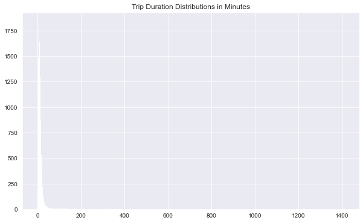

```python
plt.figure(figsize=(10,6))
bins = np.arange(0, ford_bike_clean['duration_min'].max()+0.1, 0.1)

plt.hist(ford_bike_clean.duration_min, bins=bins)

plt.title('Trip Duration Distributions in Minutes');
```

The distribution of the plot above isn't giving a reasonable meaning. I will go ahead to perform a log scaling on the X-axis to get a better view on the distribution of `duration_min` varible.

#### Is the distribution in minutes a normal distribution or right skewed distribution?

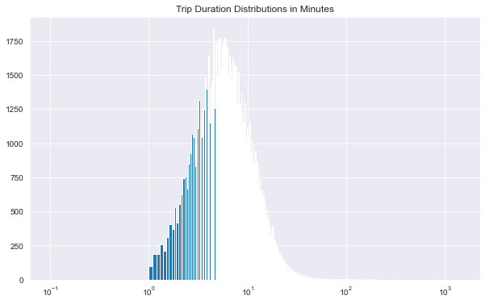

```python
plt.figure(figsize=(10,6))
bins = np.arange(0, ford_bike_clean['duration_min'].max()+0.1, 0.1)

plt.hist(ford_bike_clean.duration_min, bins=bins)
plt.xscale('log')

plt.title('Trip Duration Distributions in Minutes');
```

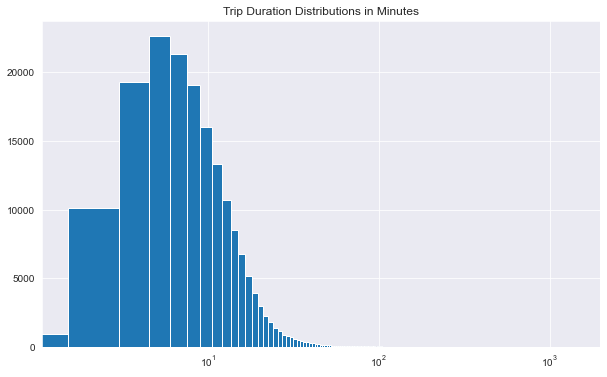

```python
plt.figure(figsize=(10,6))
bins = np.arange(0, ford_bike_clean['duration_min'].max()+1.5, 1.5)

plt.hist(ford_bike_clean.duration_min, bins=bins)
plt.xscale('log')

plt.title('Trip Duration Distributions in Minutes');
```

This plot shows that the distibution of the `duration_min` is a normal distribution with a long right tail.

#### Which day do users ride bike more?

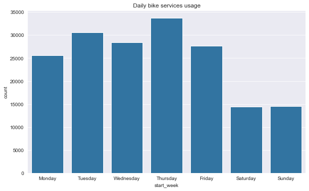

```python
day_order = ['Monday', 'Tuesday', 'Wednesday', 'Thursday', 'Friday', 'Saturday', 'Sunday']

plt.figure(figsize=(10,6))
base_color = sns.color_palette()[0]
sns.countplot(data=ford_bike_clean, x='start_week', color=base_color, order=day_order);
plt.xlabel('start_week')
plt.title('Daily bike services usage');
```

#### What are the peak hours?

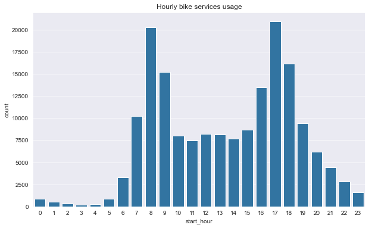

```python
plt.figure(figsize=(10,6))
base_color = sns.color_palette()[0]

sns.countplot(data=ford_bike_clean, x='start_hour', color= base_color);
plt.title('Hourly bike services usage');
```

#### Which stations are the mostly used stations?

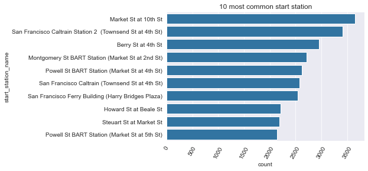

```python
# Recalculating the type_counts just to have clarity.
n_start_station = ford_bike_clean['start_station_name'].value_counts().sum()
start_station_counts = ford_bike_clean['start_station_name'].value_counts() .head(10)

# plotting the distribution of start_station_name
base_color = sns.color_palette()[0]
order = start_station_counts.index
sns.countplot(data=ford_bike_clean, y='start_station_name', color=base_color, order=order);


# Labeling the axes
plt.ylabel('start_station_name')
plt.xlabel('count')
plt.title('10 most common start station')
plt.xticks(rotation=60)

# Dsiplay the plot
plt.show()
```

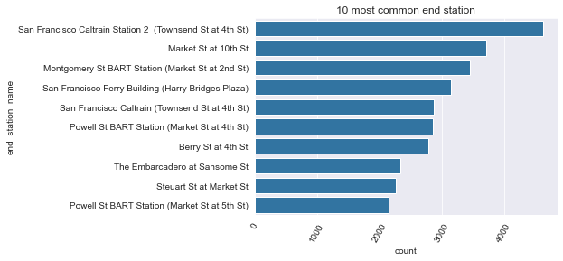

```python
# Recalculating the type_counts just to have clarity.
n_end_station = ford_bike_clean['end_station_name'].value_counts().sum()
end_station_counts = ford_bike_clean['end_station_name'].value_counts() .head(10)

# plotting the distribution of end_station_name
base_color = sns.color_palette()[0]
order = end_station_counts.index
sns.countplot(data=ford_bike_clean, y='end_station_name', color=base_color, order=order);


# Labeling the axes
plt.ylabel('end_station_name')
plt.xlabel('count')
plt.title('10 most common end station')
plt.xticks(rotation=60)

# Dsiplay the plot
plt.show()
```

```python
es = ford_bike_clean['end_station_name'].value_counts() .head(10)
ss = ford_bike_clean['start_station_name'].value_counts() .head(10)


for element in es.index:
    if element in ss:
        print(element)
```

```
San Francisco Caltrain Station 2  (Townsend St at 4th St)
Market St at 10th St
Montgomery St BART Station (Market St at 2nd St)
San Francisco Ferry Building (Harry Bridges Plaza)
San Francisco Caltrain (Townsend St at 4th St)
Powell St BART Station (Market St at 4th St)
Berry St at 4th St
Steuart St at Market St
Powell St BART Station (Market St at 5th St)
```

#### Which stations are the least used stations?

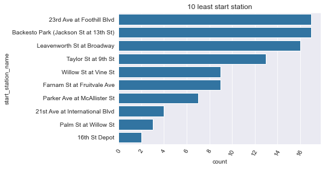

```python
# Recalculating the type_counts just to have clarity.
n_start_station = ford_bike_clean['start_station_name'].value_counts().sum()
start_station_counts = ford_bike_clean['start_station_name'].value_counts() .tail(10)

# plotting the distribution of start_station_name
base_color = sns.color_palette()[0]
order = start_station_counts.index
sns.countplot(data=ford_bike_clean, y='start_station_name', color=base_color, order=order);


# Labeling the axes
plt.ylabel('start_station_name')
plt.xlabel('count')
plt.title('10 least start station')
plt.xticks(rotation=60)

# Dsiplay the plot
plt.show()
```

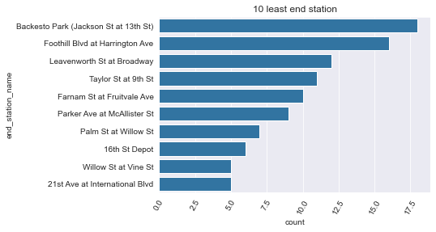

```python
# Recalculating the type_counts just to have clarity.
n_end_station = ford_bike_clean['end_station_name'].value_counts().sum()
end_station_counts = ford_bike_clean['end_station_name'].value_counts() .tail(10)

# plotting the distribution of end_station_name
base_color = sns.color_palette()[0]
order = end_station_counts.index
sns.countplot(data=ford_bike_clean, y='end_station_name', color=base_color, order=order);


# Labeling the axes
plt.ylabel('end_station_name')
plt.xlabel('count')
plt.title('10 least end station')
plt.xticks(rotation=60)

# Dsiplay the plot
plt.show()
```

```python
les = ford_bike_clean['end_station_name'].value_counts() .tail(10)
lss = ford_bike_clean['start_station_name'].value_counts() .tail(10)


for element in les.index:
    if element in lss:
        print(element)
```

```
Backesto Park (Jackson St at 13th St)
Leavenworth St at Broadway
Taylor St at 9th St
Farnam St at Fruitvale Ave
Parker Ave at McAllister St
Palm St at Willow St
16th St Depot
Willow St at Vine St
21st Ave at International Blvd
```

#### What is the gender distribution?

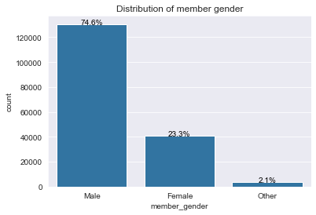

```python
# Recalculating the type_counts just to have clarity.
n_user = ford_bike_clean['member_gender'].value_counts().sum()
user_type_counts = ford_bike_clean['member_gender'].value_counts()

# plotting the distribution of member gender
base_color = sns.color_palette()[0]
order = user_type_counts.index
sns.countplot(data=ford_bike_clean, x='member_gender', color=base_color, order=order);


# get the current tick locations and labels
locs, labels = plt.xticks()

# loop through each pair of locations and labels
for loc, label in zip(locs, labels):

    # get the text property for the label to get the correct count
    count = user_type_counts[label.get_text()]
    pct_string = '{:0.1f}%'.format(100*count/n_user)

    # print the annotation just below the top of the bar
    plt.text(loc, count+2, pct_string, ha = 'center', color = 'black')

# Labeling the axes
plt.xlabel('member_gender')
plt.title('Distribution of member gender')

# Dsiplay the plot
plt.show()
```

From the plot above, it shows that there are more male bike users than othe gender.

#### What are the category of bike users?

```python
ford_bike_clean['user_type'].value_counts()
```

```
Subscriber    158386
Customer       16566
Name: user_type, dtype: int64
```

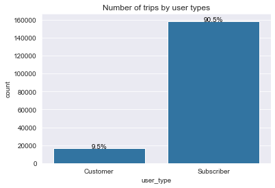

```python
# plotting the distribution of user type
base_color = sns.color_palette()[0]
sns.countplot(data=ford_bike_clean, x='user_type', color=base_color);


# Recalculating the type_counts just to have clarity.
n_user = ford_bike_clean['user_type'].value_counts().sum()
user_type_counts = ford_bike_clean['user_type'].value_counts()

# get the current tick locations and labels
locs, labels = plt.xticks()

# loop through each pair of locations and labels
for loc, label in zip(locs, labels):

    # get the text property for the label to get the correct count
    count = user_type_counts[label.get_text()]
    pct_string = '{:0.1f}%'.format(100*count/n_user)

    # print the annotation just below the top of the bar
    plt.text(loc, count+2, pct_string, ha = 'center', color = 'black')

# Labeling the axes
plt.xlabel('user_type')
plt.title('Number of trips by user types')

# Dsiplay the plot
plt.show()
```

From the plot above, we can the that 90.5% users are subscribers while 9.5% users are customers.

#### What is the age distribution?

```python
ford_bike_clean['member_age'].value_counts().head(5)
```

```
34    10214
29     9323
33     8967
32     8640
31     8484
Name: member_age, dtype: int64
```

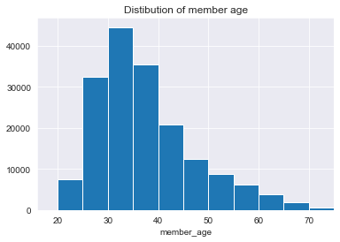

```python
# plotting the age distribution

bins = np.arange(0, ford_bike_clean['member_age'].max()+5, 5)
plt.hist(data = ford_bike_clean, x = 'member_age', bins = bins)

# Labeling the axes
plt.xlabel('member_age')
plt.title('Distibution of member age')
plt.xlim(16,75)

# Dsiplay the plot
plt.show()
```

From the `value_counts` function, it is shown that members of age 34 are the highest bike users.

The graph above shows that the distibution is right-skewed with the peak age between ages 30-35. It also shows that as the age of members increases, the user count decreases.

### Discuss the distribution(s) of your variable(s) of interest. Were there any unusual points? Did you need to perform any transformations?

> - The distribution of the `start_hour` is bimodal
> - The `member_age` distibution is a right skewed distribution.
> - The interpretation of `duration_min` distibution wasn't meaningful, I had to perform a logarithm scale on the x-axis to get a better interpretation which was a normal distribution with a long right tail.

### Of the features you investigated, were there any unusual distributions? Did you perform any operations on the data to tidy, adjust, or change the form of the data? If so, why did you do this?

> - Because the seconds variable was not providing accurate information, I modified the duration from seconds to minutes. For better investigation, I have included the columns `member_age`, `start_hour`, `week_day`.

## Bivariate Exploration

> In this section, investigate relationships between pairs of variables in your data. Make sure the variables that you cover here have been introduced in some fashion in the previous section (univariate exploration).

#### What is the relationship between age and duration in minutes?

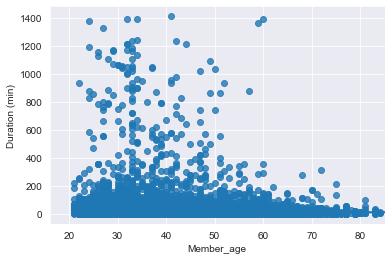

```python
# plot the relationship between 'member_age' and'duration_min'

sns.regplot(data = ford_bike_clean, x = 'member_age', y = 'duration_min');
plt.xlabel('Member_age')
plt.ylabel('Duration (min)')
plt.xlim(16,85);
```

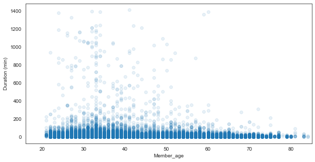

```python
# Alternative way to plot with the transparency.
sns.set_style('white')

plt.figure(figsize = [10, 5])

plt.scatter(data = ford_bike_clean, x = 'member_age', y = 'duration_min', alpha=1/10)
plt.xlabel('Member_age')
plt.ylabel('Duration (min)')
plt.xlim(16,85);
```

#### Which gender spend more time their duration trip?

```python
gen = ford_bike_clean.groupby(['member_gender'])['duration_sec'].count()
gen
```

```
member_gender
Female     40805
Male      130500
Other       3647
Name: duration_sec, dtype: int64
```

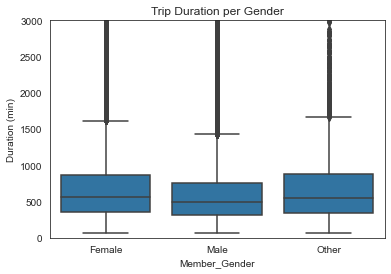

```python
# plot relationship between duration_min and gender

base_color = sns.color_palette()[0]

sns.boxplot(data=ford_bike_clean, x='member_gender', y='duration_sec', color=base_color)
plt.xlabel('Member_Gender')
plt.ylabel('Duration (min)')
plt.ylim([0, 3000])
plt.title('Trip Duration per Gender');
```

From the plot above, It is shown that female tends to spend more time on a trip than male.

#### Which cateogry of users spend more time their duration trip?

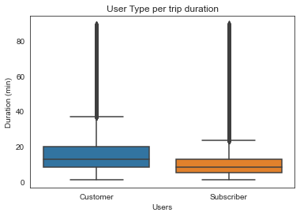

```python
# plot relationship between duration_min and bike share
ride = ford_bike_clean.query('duration_min < 90')

ax = sns.boxplot(data = ride, x = 'user_type', y = 'duration_min')
ax.set(xlabel= 'Users', ylabel='Duration (min)', title='User Type per trip duration')
plt.show()
```

This plot shows that there customers spends more time on a trip than subscribers.

#### Which day of the week do cateogry of users use the bike service?

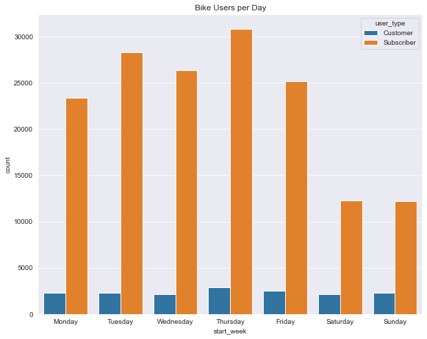

```python
# plot the relationship between user_type and start_week

plt.figure(figsize = [10, 8])
day_order = ['Monday', 'Tuesday', 'Wednesday', 'Thursday', 'Friday', 'Saturday', 'Sunday']


sns.set_style('darkgrid')

ax = sns.countplot(x ='start_week', hue = 'user_type', data = ford_bike_clean, order=day_order)
ax.set_title('Bike Users per Day');
```

From the plot above, it is shown that both customers and subscribers uses the bike services during the weekdays especially on Thursdays than the weekends.

#### What is the peak hour cateogry of users use the bike service?

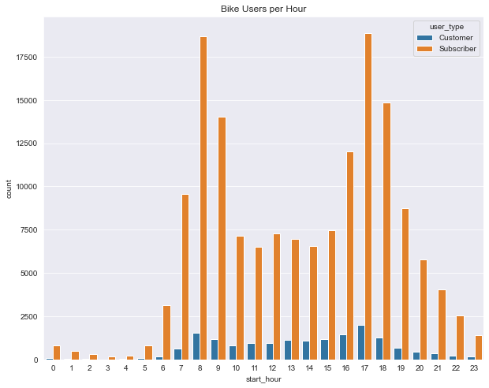

```python
# plot the relationship between user_type and start_hour

plt.figure(figsize = [10, 8])

sns.set_style('darkgrid')

ax = sns.countplot(x ='start_hour', hue = 'user_type', data = ford_bike_clean)
ax.set_title('Bike Users per Hour');
```

From the plot, it is shown that this is a bimodal plot. It also shows that there are 2 peak periods daily which are 8AM and 5PM. The reason for this is that by 8AM most customers and subscribers go to their various work places, schools, execrises and so on. Same as 5PM, most users are returning from schools, offices etc.

### Did you observe any interesting relationships between the other features (not the main feature(s) of interest)?

> I observed that from 10AM - 3PM there is a massive drop rate at which users (customers and subscribers) uses the bike services. This might be due to increase in temperature or most users are busy with their various work.

## Multivariate Exploration

> Create plots of three or more variables to investigate your data even further. Make sure that your investigations are justified, and follow from your work in the previous sections.

#### What day do the category of users spend more time using the bike services?

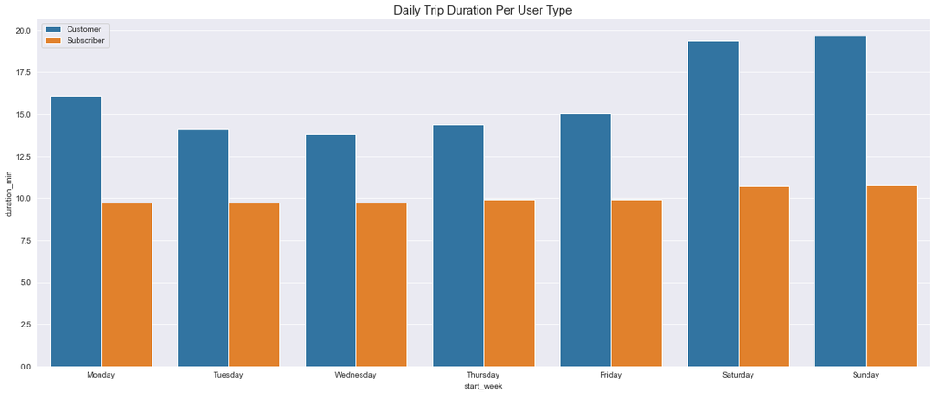

```python
plt.figure(figsize=(20,8))

day_order = ['Monday', 'Tuesday', 'Wednesday', 'Thursday', 'Friday', 'Saturday', 'Sunday']

plt.title('Daily Trip Duration Per User Type', fontsize=15)
sns.barplot(data=ride, y='duration_min', x='start_week', ci=None, hue='user_type', order=day_order)


# Remove legend title
sns.despine(fig=None, ax=None, top=True, right=True, left=True, bottom=False, offset=None, trim=False)
plt.gca().legend().set_title('');
```

From the plot above, it shows that both subscriber and customer user type spend more time on the trip duration during the weekends than the weekdays. This is because, most users do not go to their various offices and schools during the weekend. They tend to spend more time on running errands, exercises an so on.

#### At what time do category of users and age of users use the bike services?

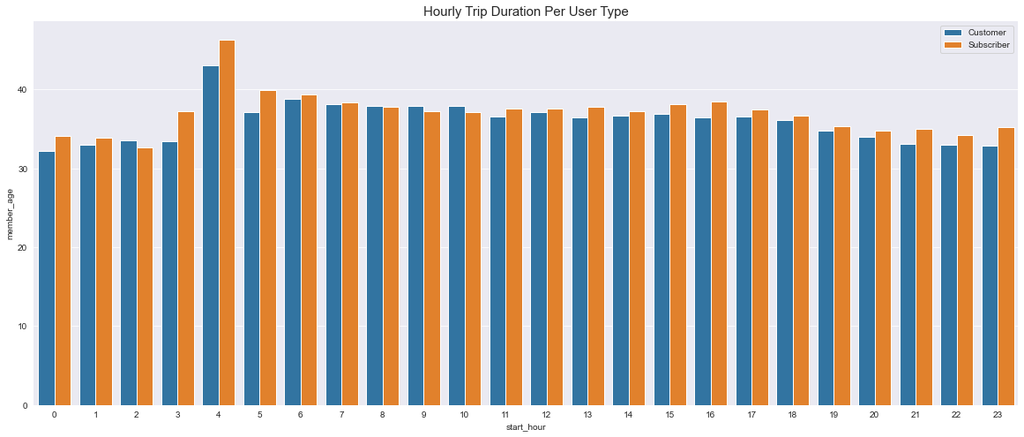

```python
plt.figure(figsize=(20,8))
plt.title('Hourly Trip Duration Per User Type', fontsize=15)
sns.barplot(data=ford_bike_clean, y='member_age', x='start_hour', ci=None, hue='user_type')

sns.despine(fig=None, ax=None, top=True, right=True, left=True, bottom=False, offset=None, trim=False)
plt.gca().legend().set_title('');
```

This plot shows that both subscribers and customer users above age 40 years tend to go for a ride at 4AM. This might be because they all go for exercise early mornings.

```python
# saving the clean dataset into a csv file
ford_bike_clean.to_csv('ford_bike_clean.csv', encoding = 'utf-8', index = False)
```

### Conclusion

#### Limitations:

- There were lots of outliers in the `age`, `duration_sec` columns.
- There were lots of missing data.